STANDARD SCM & AUGMENTED SCM

# Estimating Donor Weights: Step 1 — SCM • Step 2 — Ridge ASCM

Ben-Michael, Feller & Rothstein (2021) • All 8 Sentinel-2 bands × 7 periods stacked

56-row design matrix (8 bands × 7 periods) SCM: w ≥ 0, Σw=1 ASCM: ridge + drop non-negativity

## Input Data — All 8 Bands × 7 Periods Stacked (56 rows, used by BOTH SCM & ASCM)

STACKED DESIGN MATRIX

$$\mathbf{y}_1\in\mathbb{R}^{56},\quad \mathbf{Y}_0\in\mathbb{R}^{56\times5}$$ $$\text{Row }(t,k)=\text{period }t\text{, band }k\text{ (standardised)}$$

| Row | Period | Band | Treat (y₁) | CF-01 | … | CF-05 |
| --- | --- | --- | --- | --- | --- | --- |
| 1 | P01 | B2 | -1.058 | -0.442 | … | -0.830 |
| 2 | P01 | B3 | -1.003 | -0.672 | … | -0.538 |
| ⋮ periods P02, P04, P05, P07, P08 — 40 rows ⋮ |  |  |  |  |  |  |
| 49 | P09 | B2 | 1.723 | -0.442 | … | -0.830 |
| 56 | P09 | NDWI | 0.713 | -0.705 | … | -0.946 |

Standardised per band using donor pool mean & std (ddof=0) from training periods only • NaN rows dropped

Period P09 block (rows 49–56) — treatment site 0001:

| Band | Treat | CF-01 | CF-02 | CF-03 | CF-04 | CF-05 |
| --- | --- | --- | --- | --- | --- | --- |
| B2 | 1.723 | -0.442 | -0.403 | 1.967 | -0.292 | -0.830 |
| B3 | 1.496 | -0.672 | -0.455 | 1.987 | -0.322 | -0.538 |
| B4 | 1.084 | -0.802 | 0.220 | 1.840 | -0.373 | -0.885 |
| B8 | 1.379 | -0.122 | -1.768 | 1.276 | 0.157 | 0.456 |
| B11 | -0.701 | -1.143 | 1.390 | 0.994 | -0.578 | -0.663 |
| B12 | -0.520 | -0.995 | 1.408 | 0.993 | -0.542 | -0.864 |
| NDVI | -0.263 | 0.767 | -0.999 | -1.387 | 0.512 | 1.107 |
| NDWI | 0.713 | -0.705 | 0.423 | 1.771 | -0.543 | -0.946 |

Same 8-band matrix is input to **both SCM and ASCM** — only the solver & constraints differ

## Step 1 — Standard SCM: Simplex-Constrained Least Squares

OBJECTIVE

$$\mathbf{w}^{\rm SCM}=\underset{w_j\geq0,\,\sum w_j=1}{\arg\min}\,\|\mathbf{y}_1-\mathbf{Y}_0\mathbf{w}\|^2$$

Inputs: y₁∈ℝ<sup>56</sup>, Y₀∈ℝ<sup>56×5</sup>

QP FORM

$$D=\mathbf{Y}_0^\top\mathbf{Y}_0+\varepsilon I_J$$ $$\mathbf{d}=\mathbf{Y}_0^\top\mathbf{y}_1$$ $$\min_w\tfrac{1}{2}\mathbf{w}^\top D\mathbf{w}-\mathbf{d}^\top\mathbf{w}$$ $$\text{s.t. }\mathbf{1}^\top\mathbf{w}=1,\;\mathbf{w}\geq\mathbf{0}$$

PYTHON (SLSQP)

D = Y0.T @ Y0 + 1e-7*eye(J)  
d = Y0.T @ y1  
minimize(obj, w0,  
method='SLSQP',  
bounds=[(0,1)]*J,  
constraints=[sum(w)==1]  
)

D = Y₀ᵀY₀ (5×5)

$$D_{ij}=\sum_{t,k} Y_{0,tki}\cdot Y_{0,tkj}$$

Sum over all 56 (period, band) pairs

|  | CF-01 | CF-02 | CF-03 | CF-04 | CF-05 |
| --- | --- | --- | --- | --- | --- |
| CF-01 | 4.69 | -3.53 | -8.27 | 2.60 | 4.52 |
| CF-02 | -3.53 | 8.63 | 1.37 | -2.40 | -4.07 |
| CF-03 | -8.27 | 1.37 | 19.86 | -4.49 | -8.47 |
| CF-04 | 2.60 | -2.40 | -4.49 | 1.54 | 2.75 |
| CF-05 | 4.52 | -4.07 | -8.47 | 2.75 | 5.28 |

Values shown from P09×8bands block as illustration

SCM WEIGHTS w* (treatment_0001)

| CF-01 | +0.4410 |  |
| --- | --- | --- |
| CF-02 | +0.0000 |  |
| CF-03 | +0.0311 |  |
| CF-04 | +0.5279 |  |
| CF-05 | +0.0000 |  |

## Step 2 — Augmented SCM: Ridge Penalty Anchored to w<sub>SCM</sub>

ASCM OBJECTIVE

$$\mathbf{w}^{\rm ASCM}=\underset{\sum w_j=1}{\arg\min}\,\|\mathbf{y}_1-\mathbf{Y}_0\mathbf{w}\|^2+\lambda\|\mathbf{w}-\mathbf{w}^{\rm SCM}\|^2$$

**Drop** w≥0 • **Add** ridge to anchor near w<sub>SCM</sub>

MODIFIED QP MATRICES

$$D^{\rm ASCM}=D^{\rm SCM}+\lambda I_J$$ $$\mathbf{d}^{\rm ASCM}=\mathbf{d}^{\rm SCM}+\lambda\,\mathbf{w}^{\rm SCM}$$

Large λ inflates diagonal of D • pulls solution toward w<sub>SCM</sub>

$$D^{\rm ASCM}_{\rm diag}=[10005, 10009, 10020, 10002, 10005]$$

λ=10,000 added to each diagonal entry

KKT CLOSED-FORM

H = eye(J)+(Y0.T@Y0)/lam  
b = w_scm+(Y0.T@y1)/lam  
KKT=block([[H,ones],  
[ones.T,[[0]]]])  
rhs=r_[b,[1.0]]  
w = solve(KKT,rhs)[:J]

λ via leave-one-period-out CV • treatment_0001: λ*=10,000

ASCM WEIGHTS (treatment_0001)

| CF-01 | +0.4414 |  |
| --- | --- | --- |
| CF-02 | -0.0009 |  |
| CF-03 | +0.0315 |  |
| CF-04 | +0.5283 |  |
| CF-05 | -0.0003 |  |

CF-02 and CF-05 slightly negative (allowed) • Very close to SCM (λ large)

EFFECT OF λ

λ→∞: ASCM = SCM  
λ→0: unconstrained OLS (most flexible)

| Aspect | SCM | ASCM |
| --- | --- | --- |
| Constraints | w≥0, Σw=1 | Σw=1 only |
| Penalty | None | λ∥w−w<sub>SCM</sub>∥² |
| Solver | SLSQP | KKT linear |
| Neg. weights? | No | Yes |

## Why Multiple Outcomes? Formal Bias Reduction O(1/√KT₀)

STANDARD SCM — 1 OUTCOME

$$\text{Bias}=O\!\left(\frac{1}{\sqrt{T_0}}\right)$$

T₀=7 periods, K=1 → effective mass = 7

MULTI-OUTCOME SCM — K OUTCOMES

$$\text{Bias}=O\!\left(\frac{1}{\sqrt{K\cdot T_0}}\right)$$

K=8, T₀=7 → effective mass = 56 **(8× more)**

KEY CONDITION

All K outcomes must share a common latent factor μₜ:

$$Y_{{ikt}}=\mu_t^\top\lambda_{{ik}}+\delta_{{ikt}}+\varepsilon_{{ikt}}$$

Sentinel-2 bands all driven by vegetation, moisture & soil structure → valid grouping

THREE APPLICATIONS

| Study | T₀ | K | Matching rows |
| --- | --- | --- | --- |
| Germany | 1 yr (1989) | 9 econ. | 9 |
| COVID | >1 qtrs | 3–6/domain | K×T₀ (filtered) |
| Sentinel-2 | 7 periods | 8 bands | 56 |

Same mathematical structure — same solver — different context

## Germany Example: T₀=1 × K=9 — Equation, Matrix & Code

SETUP

**Treated:** West Germany • **Event:** Reunification 1990  
**Standard SCM:** T₀=30 yrs, K=1 (GDP only)  
**SCM-MO:** T₀=1 (1989 only), K=9  
**Donors:** J=16 OECD countries

9 MATCHING OUTCOMES (1989)

| # | Variable |
| --- | --- |
| 1 | Private social expenditure |
| 2 | Total energy supply per GDP |
| 3 | Electricity generation |
| 4 | Triadic patent families |
| 5 | Real GDP growth rate |
| 6 | CPI: all items |
| 7 | Trade openness |
| 8 | Total tax revenue |
| 9 | GDP per capita |

KEY EQUATIONS

$$Z\in\mathbb{R}^{17\times9}\text{ (countries \times outcomes)}$$ $$V=\text{diag}\!\left(\tfrac{1}{9},\ldots,\tfrac{1}{9}\right)$$ $$D=Z_J V Z_J^\top\in\mathbb{R}^{16\times16}$$ $$\mathbf{d}=Z_J V \mathbf{z}_i\in\mathbb{R}^{16}$$ $$\hat{\mathbf{w}}=\underset{w\geq0,\,\mathbf{1}'w=1}{\arg\min}\;\frac{1}{2}w^\top D\,w - \mathbf{d}^\top w$$

Z MATRIX (standardised, 1989 values — illustrative)

| Country | Soc.Exp | Energy | Elec. | Patents | GDP.gr | CPI | Trade | Tax | GDP.cap |
| --- | --- | --- | --- | --- | --- | --- | --- | --- | --- |
| W.Ger | 1.21 | -0.43 | 0.87 | 1.95 | 0.32 | -0.71 | 0.18 | 0.94 | 1.43 |
| Austria | 0.84 | 0.22 | 0.53 | -0.31 | 0.61 | 0.15 | 0.74 | 0.42 | 0.91 |
| Belgium | 1.03 | -0.11 | 0.41 | 0.22 | -0.48 | 0.63 | 1.52 | 1.21 | 1.02 |
| ⋮ 13 more donors ⋮ |  |  |  |  |  |  |  |  |  |
| USA | -0.52 | 0.88 | -0.34 | 0.71 | 0.22 | 0.94 | -0.83 | -0.66 | 0.88 |

Standardised by cross-country SD • Z<sub>J</sub>∈ℝ<sup>16×9</sup> (donors) • zᵢ∈ℝ<sup>9</sup> (W.Germany)

fn_W SOLVER (used for both Germany & COVID)

fn_W = function(Zi, ZJ, V) {  
J = nrow(ZJ)  
D = ZJ %*% V %*% t(ZJ) + 1e-7*diag(J)  
d = ZJ %*% V %*% Zi  
A = cbind(rep(1,J), diag(J))  
solve.QP(D, d, A, c(1,rep(0,J)), meq=1)$solution  
}

FULL R CODE (Germany.R)

# Select 9 outcomes for T0=1989 only  
data1 = data[, c(  
"Private social expenditure",  
"Total primary energy supply per unit of GDP",  
"Electricity generation",  
"Triadic patent families",  
"Real GDP growth",  
"CPI: all items",  
"Trade openness",  
"Total tax revenue",  
"GDP per capita")]  
# Drop columns with any NA  
Z = Z[, complete.cases(t(Z))]  
# Standardise by column SD (no demeaning)  
Z = scale(Z, center=F, scale=apply(Z,2,sd))  
# Equal V: 1/9 per outcome  
V = rep(1/ncol(Z), ncol(Z))  
# Solve: W1 in R^16  
W1 = fn_W(Z[WGermany,], Z[donors,],  
diag(V, ncol(Z)))  
# Synthetic Germany GDP  
synthY01 = t(Y[donors,]) %*% W1

## COVID (Synthetic Sweden): T₀=6 Quarters × K=3 Outcomes — Health Domain

THREE DOMAINS

| Domain | K outcomes | J donors |
| --- | --- | --- |
| Public Health ✓ | 3 (cases, deaths, all-cause) | 25 |
| Labour | 3 (employ., absence, hours) | 25 |
| Economy | 6 (GDP, imports, exports, ...) | 26 |

One **w** per domain • Health: M = 3 outcomes × 6 quarters = 18 cells

KEY EQUATIONS

$$Z\in\mathbb{R}^{26\times18}\;\text{(countries}\times\text{cells)}$$

**Step 1 — Demean within country×outcome:**

$$\tilde{Y}_{ikt}=Y_{ikt}-\bar{Y}_{ik,\text{pre}}$$

**Step 2 — Standardise cross-country per cell:**

$$Z_{ikt}=\tilde{Y}_{ikt}\,/\,\hat{\sigma}_{kt},\quad\hat{\sigma}_{kt}=\text{sd}_{\text{donors}}(\tilde{Y}_{\cdot kt})$$

**Step 3 — V (equal total weight per outcome):**

$$v_{kt}=\frac{1}{M_k},\;M_k=\text{\# usable cells for outcome }k$$

Z MATRIX — HEALTH DOMAIN (illustrative standardised values)

| Country | Cases Q1 | Cases Q2 | ⋯ | Deaths Q1 | Deaths Q2 | ⋯ | A-cause Q1 | ⋯ |
| --- | --- | --- | --- | --- | --- | --- | --- | --- |
| Sweden | 1.84 | 2.11 | ⋯ | 1.52 | 1.73 | ⋯ | 0.93 | ⋯ |
| Austria | -0.31 | -0.44 | ⋯ | -0.27 | -0.38 | ⋯ | 0.42 | ⋯ |
| Belgium | 0.73 | 0.91 | ⋯ | 1.04 | 0.88 | ⋯ | -0.15 | ⋯ |
| ⋯ 22 more donors ⋯ |  |  |  |  |  |  |  |  |
| UK | 0.65 | 0.72 | ⋯ | 0.81 | 0.77 | ⋯ | -0.44 | ⋯ |

Z<sub>J</sub>∈ℝ<sup>25×18</sup> (25 donors) • z<sub>SWE</sub>∈ℝ<sup>18</sup> (1 row, treatment) • Sweden's high values → sparse weights on donors

fn_W SOLVER (same as Germany)

fn_W = function(Zi, ZJ, V) {  
J = nrow(ZJ)  
D = ZJ %*% V %*% t(ZJ) + 1e-7*diag(J)  
d = ZJ %*% V %*% Zi  
A = cbind(rep(1,J), diag(J))  
solve.QP(D, d, A, c(1,rep(0,J)), meq=1)$solution  
}

R CODE (COVID_analysis.R)

# Demean within country x outcome  
for(i in 1:N) for(k in outcomes[[s]])  
Ymat_d[i,k,pre] = Ymat[i,k,pre]  
- mean(Ymat[i,k,pre])  
# Build Z: rows=countries, cols=cells  
for(i in 1:N) {  
row_i = NULL  
for(k in outcomes[[s]])  
row_i=c(row_i, Ymat_d[i,k,pre])  
Z = rbind(Z, row_i)  
}  
# Drop zero-SD; standardize per cell  
Z = Z[, apply(Z[-SWE,],2,sd) > 0]  
for(col in 1:ncol(Z))  
Z[,col]=Z[,col]/sd(Z[-SWE,col])  
# V: equal total weight per outcome  
V=NULL  
for(k in outcomes[[s]]) {  
cnt=sum(cols_k==k)  
V=c(V, rep(1/cnt, cnt))  
}  
# Solve: W[,3] = demeaned benchmark  
W_SWE[[s]] = fn_W(  
Z[SWE,], Z[-SWE,], diag(V))[,3]  
# Level restore post-estimation  
synthY1 = synthY1  
- mean(synthY1[dates<=treat])  
+ mean(Yi[dates<=treat])

THREE SPECIFICATIONS

| Col | Name | Demeaning |
| --- | --- | --- |
| W[,1] | Backdate (BD) | Backdated pre-period |
| W[,2] | No-demean (ND) | None |
| W[,3] | Demean (DM) ✓ | Per country×outcome |

**W_SWE[[s]]=W[,3]** = benchmark • Level restored after weighting

## COVID SCM-MO — Estimation Pipeline (One Domain at a Time)

Choose one domain (public health • labour • economy)

↓

Stack all outcome × pre-period observations → Z∈ℝ<sup>N×M</sup>

↓

↓

Remove incomplete / zero-SD cells

↓

↓

*V*: equal total weight per outcome v<sub>tk</sub> = 1/M<sub>k</sub>

↓

Z<sub>i</sub> = M×1 Z<sub>J</sub> = J×M

↓

min<sub>W</sub> (Z<sub>i</sub> − Z<sub>J</sub>′W)′ V (Z<sub>i</sub> − Z<sub>J</sub>′W) s.t. W ≥ 0, **1**′W = 1

↓

One common donor-weight vector for the whole domain W∈ℝ<sup>J</sup>

## Sentinel-2 Exp1: Z<sub>J</sub>∈ℝ<sup>5×8</sup> — 5 Donor Rows × 8 Band Columns (Period P09)

DIMENSIONS (same structure as Germany T₀=1)

$$Z_J\in\mathbb{R}^{5\times8},\quad\mathbf{z}_i\in\mathbb{R}^{8},\quad\mathbf{w}\in\mathbb{R}^{5}$$

| Dimension | This study | Germany |
| --- | --- | --- |
| Rows (sites) | 5 donors | 16 donors |
| Cols (outcomes) | 8 bands | 9 outcomes |
| Periods T₀ | 1 (P09) | 1 (1989) |

V = diag(1/8, ..., 1/8) • equal weight per band

QP OBJECTIVE

$$\hat{\mathbf{w}}=\underset{w\geq0,\,\mathbf{1}'w=1}{\arg\min}\;(\mathbf{z}_i-Z_J^\top\mathbf{w})^\top V(\mathbf{z}_i-Z_J^\top\mathbf{w})$$ $$D=Z_J V Z_J^\top\in\mathbb{R}^{5\times5},\quad\mathbf{d}=Z_J V\mathbf{z}_i\in\mathbb{R}^{5}$$

SCM-MO EXP1 WEIGHTS (P09, K=8)

| CF-01 | +0.4030 |  |
| --- | --- | --- |
| CF-02 | +0.0000 |  |
| CF-03 | +0.5970 |  |
| CF-04 | +0.0000 |  |
| CF-05 | +0.0000 |  |

Sparse • CF-01+CF-03 dominate • 3 zero weights

Z<sub>J</sub>: 5 donor rows × 8 band columns (standardised, P09) • z<sub>i</sub>: treatment row (orange):

| Site | B2 | B3 | B4 | B8 | B11 | B12 | NDVI | NDWI |
| --- | --- | --- | --- | --- | --- | --- | --- | --- |
| Treat | 1.723 | 1.496 | 1.084 | 1.379 | -0.701 | -0.520 | -0.263 | 0.713 |
| CF-01 | -0.442 | -0.672 | -0.802 | -0.122 | -1.143 | -0.995 | 0.767 | -0.705 |
| CF-02 | -0.403 | -0.455 | 0.220 | -1.768 | 1.390 | 1.408 | -0.999 | 0.423 |
| CF-03 | 1.967 | 1.987 | 1.840 | 1.276 | 0.994 | 0.993 | -1.387 | 1.771 |
| CF-04 | -0.292 | -0.322 | -0.373 | 0.157 | -0.578 | -0.542 | 0.512 | -0.543 |
| CF-05 | -0.830 | -0.538 | -0.885 | 0.456 | -0.663 | -0.864 | 1.107 | -0.946 |

D∈ℝ<sup>5×5</sup> Gram matrix — D<sub>jk</sub>=Z<sub>j</sub>·Z<sub>k</sub> summed over 8 bands:

|  | CF-01 | CF-02 | CF-03 | CF-04 | CF-05 |
| --- | --- | --- | --- | --- | --- |
| CF-01 | 4.69 | -3.53 | -8.27 | 2.60 | 4.52 |
| CF-02 | -3.53 | 8.63 | 1.37 | -2.40 | -4.07 |
| CF-03 | -8.27 | 1.37 | 19.86 | -4.49 | -8.47 |
| CF-04 | 2.60 | -2.40 | -4.49 | 1.54 | 2.75 |
| CF-05 | 4.52 | -4.07 | -8.47 | 2.75 | 5.28 |

## Sentinel-2 Exp2: Z<sub>J</sub>∈ℝ<sup>5×56</sup> — 5 Donor Rows × 8 Bands×7 Periods (Exp2)

DIMENSIONS (same structure as COVID multi-period)

$$Z_J\in\mathbb{R}^{5\times56},\quad\mathbf{z}_i\in\mathbb{R}^{56},\quad\mathbf{w}\in\mathbb{R}^{5}$$

| Dimension | This study | COVID (health) |
| --- | --- | --- |
| Rows (sites) | 5 donors | 25 donors |
| Outcomes K | 8 bands | 3 outcomes |
| Periods T₀ | 7 (P01–P09) | 6 quarters |
| Cols (K×T₀) | 8×7=56 | 3×6=18 |

V = diag(1/7,...) • equal total weight per band across all 7 periods

QP OBJECTIVE

$$\hat{\mathbf{w}}=\underset{w\geq0,\,\mathbf{1}'w=1}{\arg\min}\;(\mathbf{z}_i-Z_J^\top\mathbf{w})^\top V(\mathbf{z}_i-Z_J^\top\mathbf{w})$$ $$\underbrace{Z_J^\top}_{56\times5}\underbrace{\mathbf{w}}_{5\times1}=\underbrace{\hat{\mathbf{z}}_i}_{56\times1}$$

SCM-MO EXP2 WEIGHTS (P01–P09, K=8)

| CF-01 | +0.2199 |  |
| --- | --- | --- |
| CF-02 | +0.1089 |  |
| CF-03 | +0.2930 |  |
| CF-04 | +0.3782 |  |
| CF-05 | +0.0000 |  |

More dispersed • RMSE=0.0186 vs Exp1 0.0279 (−33%)

Z<sub>J</sub> condensed: 5 donor rows × selected band×period columns (56 cols total) • z<sub>i</sub>: treatment (orange):

| Site | B2×P01 | B2×P09 | ⋯ | B8×P01 | B8×P09 | ⋯ | NDWI×P01 | NDWI×P09 |
| --- | --- | --- | --- | --- | --- | --- | --- | --- |
| Treat | -1.058 | 1.723 | ⋯ | 1.097 | 1.379 | ⋯ | -1.987 | 0.713 |
| CF-01 | -0.442 | -0.442 | ⋯ | -0.122 | -0.122 | ⋯ | -0.705 | -0.705 |
| CF-02 | -0.403 | -0.403 | ⋯ | -1.768 | -1.768 | ⋯ | 0.423 | 0.423 |
| CF-03 | 1.967 | 1.967 | ⋯ | 1.276 | 1.276 | ⋯ | 1.771 | 1.771 |
| CF-04 | -0.292 | -0.292 | ⋯ | 0.157 | 0.157 | ⋯ | -0.543 | -0.543 |
| CF-05 | -0.830 | -0.830 | ⋯ | 0.456 | 0.456 | ⋯ | -0.946 | -0.946 |

Columns ordered as B2×P01, B2×P02, …, B2×P09, B3×P01, …, NDWI×P09 • shown: P01 & P09 endpoints per band

*Single weight vector **w∈ℝ<sup>5</sup>** fits all 56 band×period cells simultaneously*

## Interactive Map — Click a Treatment Site to See Donor Weights

📍 Click a red treatment site to see donor weights

Treatment site (has weights) Treatment site (no weights) Donor site ■ SCM ■ ASCM ■ SCM-MO Exp1 ■ SCM-MO Exp2

## SCM-MO Validation — P10 Hold-Out RMSE by Band (Exp2: P01–P09 × 8 Bands)

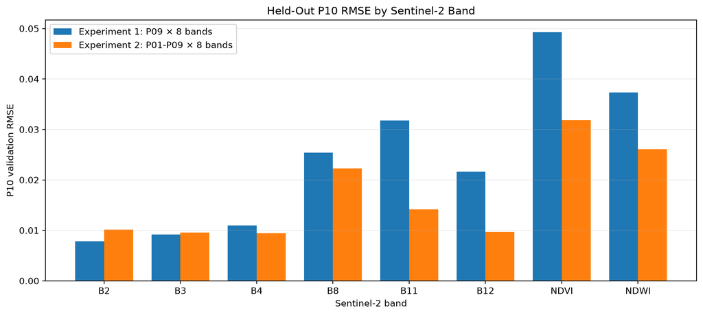

HOLD-OUT VALIDATION SETUP

**Training:** Periods P01–P09 (pre-hurricane)  
**Test:** Period P10 (post-hurricane, held out)  
**Sites:** 10 treatment sites, 5 donor forests  
**Metric:** RMSE & MAE across 8 Sentinel-2 bands

BAND RMSE RANKING

[output not shown]

Visible bands best matched • NDVI/NDWI higher RMSE reflects hurricane vegetation damage signal

## SCM vs ASCM Validation — P10 Hold-Out RMSE by Band & Site

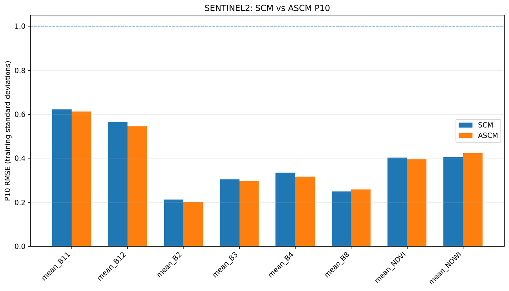

SCM vs ASCM COMPARISON

Both methods use the same 56-row design matrix (8 bands × 7 periods).  
**SCM** (λ=∞ limit): simplex-constrained, no negative weights  
**ASCM** (ridge, λ tuned by CV): allows negative weights, anchored to SCM solution

VALIDATION INTERPRETATION

OVERALL FINDING

SCM-MO Exp2 (P01–P09 × 8 bands) achieves lowest RMSE overall.  
Ridge ASCM correction minimal at λ=10,000 — SCM provides strong baseline when donor pool is small (J=5) and pre-treatment fit is already excellent.